## Tech Assignment

### 04 Dec 2023

#### Tzu-Cheng Peng

### Outline

- Problem I: Pricing
  - Direct Estimate
  - Resample & Curve Fitting
- Problem II: TS Forcasting
  - EDA (correlation & seasonality)
  - Baseline Model
  - Prophet Model

### Pricing

```
    pricing = pd.DataFrame({
'prices': [100, 90, 70, 60, 40, 20, 10],
'demand': [100, 120, 200, 300, 1200, 2000, 2800] })
```

- Find out the optimal price that maximises revenue
- `def revenue_maximizing_price():...`
- Knowing the demand (from the previous question) and the supplier price, and assuming that the only costs we have are the cost of the goods we sell, please find the price that maximizes our profits
- `def profit_maximizing_price():...`

| quantity | supplier price |
| --- | --- |
| <= 50 | 15 |
| 51-100 | 12 |
| 101-200 | 8 |
| >200 | 4 |

### Pricing: Direct Estimate

```
def revenue_maximizing_price(prices, demand)->float:

    revenue = pd.Series(prices * demand, name='revenue')
    new_df = pd.concat([prices, demand, revenue], axis=1)

    return(new_df.loc[new_df['revenue'].argmax(), 'prices'])

def profit_maximizing_price(df_pricing, df_cost)->float:

    pricing_cost = pd.merge(df_pricing, df_cost, how="cross")
    pricing_cost = pricing_cost[pricing_cost.
                    apply(lambda x: x.demand in x.quantity, axis=1)].reset_index()
    pricing_cost['profit'] = (pricing_cost.prices - pricing_cost.supplier_price)
                            * pricing_cost.demand

    return(pricing_cost.loc[pricing_cost['profit'].argmax(), 'prices'], pricing_cost)
```

### Pricing: Curve Fitting

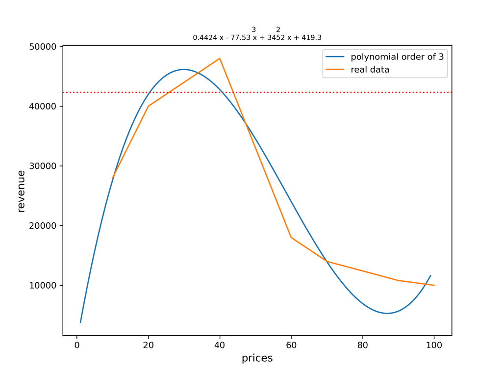

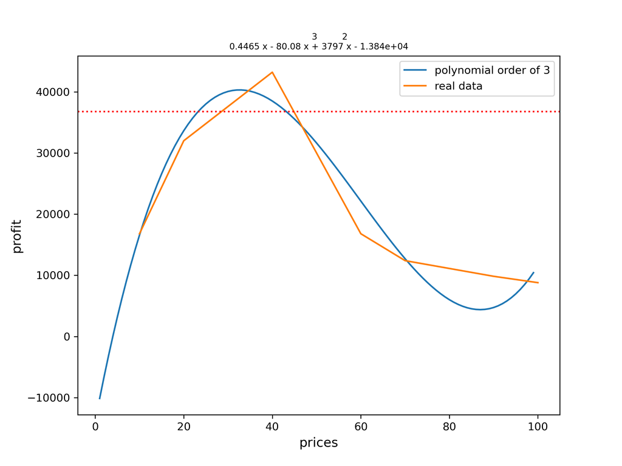

### Pricing: Discussion

- Both revenue-max and profit-max prices from the fitting data are lower than the direct calculations (i.e, 29 vs. 40 and 32 vs. 40)
- Curve fitting can have error estimates with bigger flexibility in the business sense
- Sometimes there will probably be no sweet spots for local min/max. In those cases, extra attributes, e.g., other costs, time comsumptions, or promotions, etc., could be helpful for optimizations.
- Further Improvement
  - Uncertaintiy range can be better estimated with the boosting sampling

### TS Forcasting

- What can be said about the overall trend and seasonality of sales? What of the individual product type?
- Are there correlations between sales of some product types, and if so, which?
- Select a single product type and make forecast about its sales for 5 time periods (weeks) from the last observed data point. Please include confidence interval of this forecast.

### TS Forcasting: EDA

[interactive chart not shown]

### TS Forcasting: Correlation & Seasonality

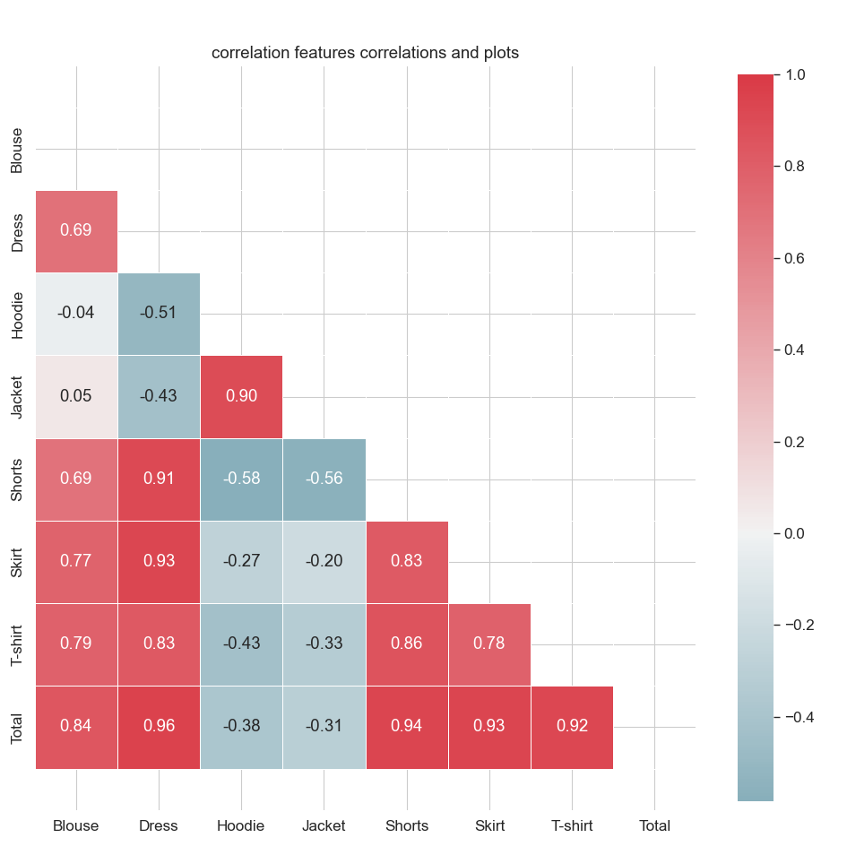

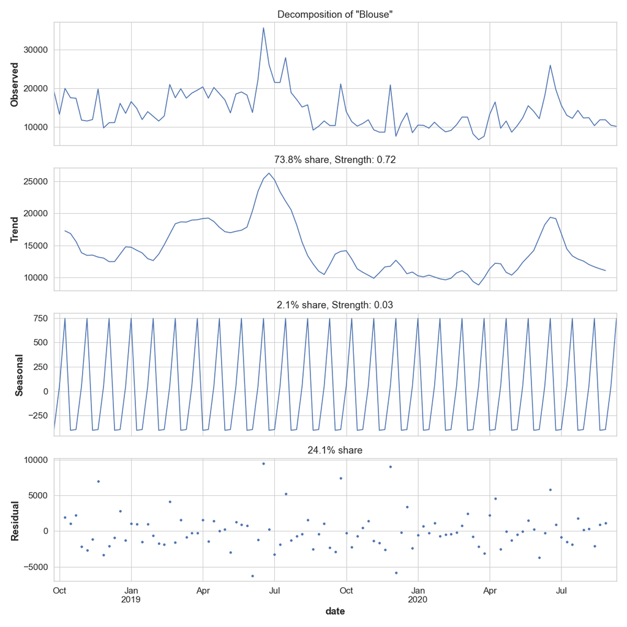

### TS Forcasting: Baseline Models

- Blouse data as the target varible
- Using Darts & Prophet packages
- With the MLflow framework
- Simple baseline models with ExponentialSmoothing, ARIMA, AutoARIMA
- TS k-fold validations
- MAPE as the main metric
- The baseline models have MAPE ~38-41%

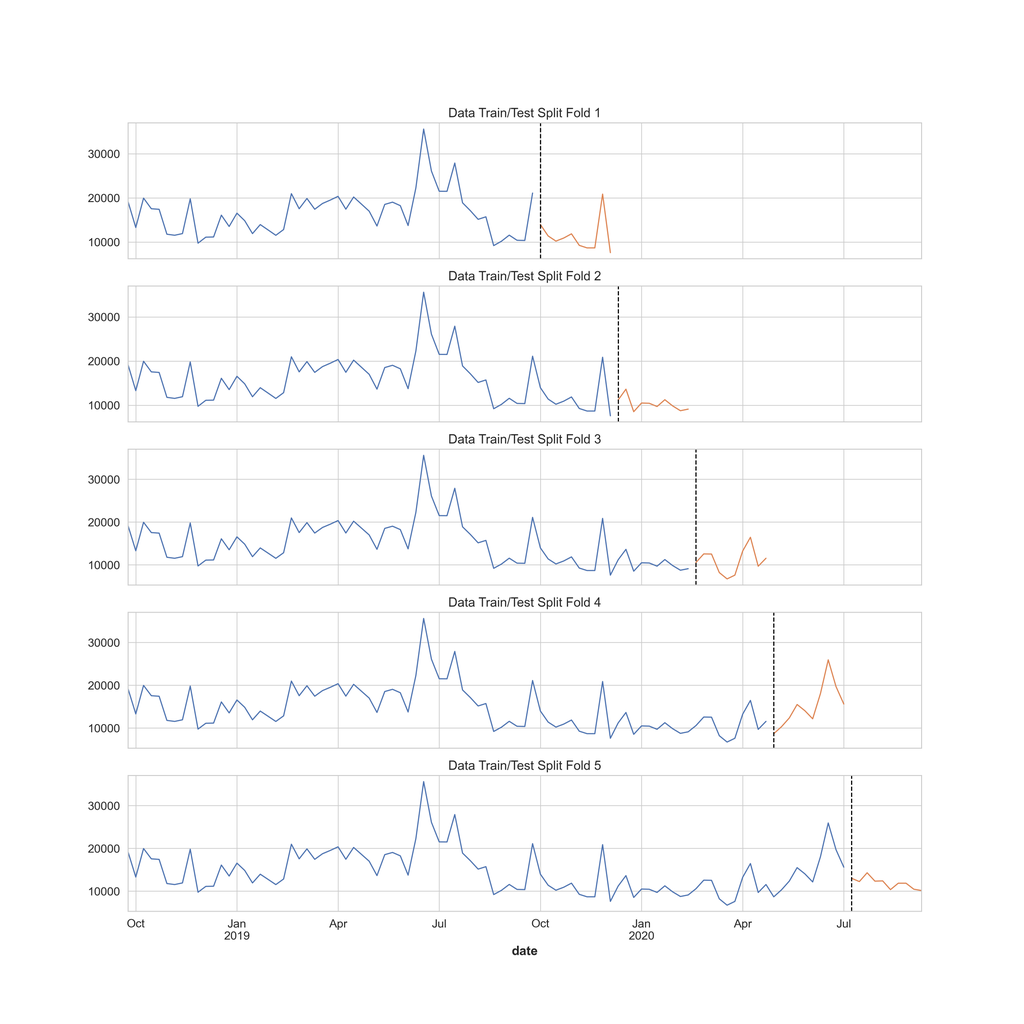

### TS Forcasting: Prophet Model I

[interactive chart not shown]

### TS Forcasting: Prophet Model II

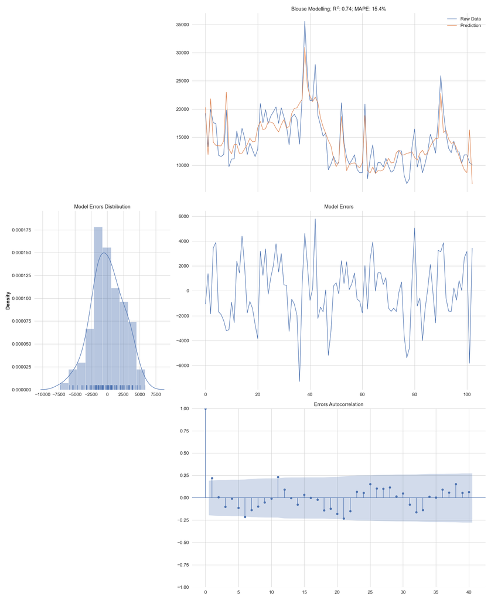

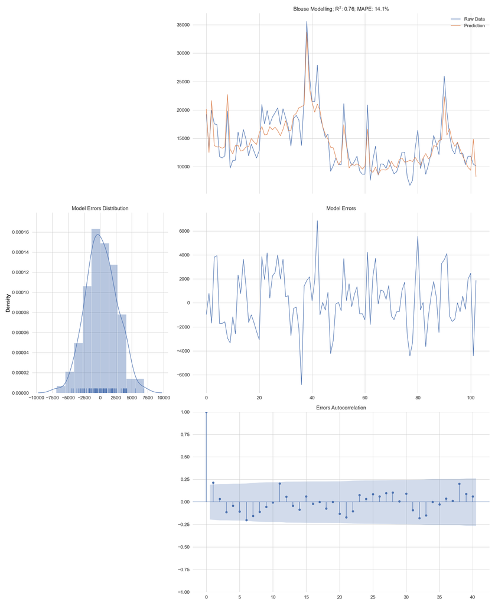

### TS Forcasting: Discussion

- The (data-transformed) training MAPE is 0.14 and validation MAPE is 0.19 (slightly overfitting)
- Error dist. is more close to Gaussian
- Error Autocorrelation doesn't show strong seasonality left
- Only few peaks are not well fitted (slightly better than the previous results)
- Further improvments:
  - grid searches for better hyperparameters
  - better estimate the holiday/sale effects
  - extra regressor with e.g., price, cost, etc.
  - multi-ts model (covariates, multivariates), NN-style model (LTSM, RNN, etc.)